# Exploracion de Datos

Irving, Chuy

2025-01-29

# Fase Exploratoria

En esta fase se hará un breve análisis de exploración del dataset en donde se conocerán datos generales, cómo el tipo de las varaibles, sus distribuciones o formas. Además se plantena preguntas superficiales para comenzar a familiarizarse con el dataset, cómo conocer las peliculas más vistas, actores, géneros más populares y otras características importantes para entender las variables.

# Exploración rapida y resumen de los datos

| **Nombre de la Columna** | **Descripción** |
| --- | --- |
| `Id` | Id de la pelicula. |
| `Popularity` | Índice de popularidad de la pelicula calculado semanalmente. |
| `budget` | Presupuesto de la pelicula. |
| `revenue` | Ingresos de la pelicula. |
| `original_title` | Título original de la pelicula (en su idioma original). |
| `originalLanguage` | Idioma original de la pelicula. |
| `title` | Título de la pelicula traducido al inglés. |
| `homePage` | Página web de la pelicula. |
| `video` | Indica si la pelicula tiene videos promocionales. |
| `director` | Director de la pelicula. |
| `runtime` | Duración de la pelicula. |
| `genres` | Género(s) de la pelicula. |
| `genresAmount` | Cantidad de géneros que representan a la pelicula. |
| `productionCompany` | companias productoras de la pelicula. |
| `productionCoAmount` | Cantidad de companias productoras que participaron en la pelicula. |
| `productionCompanyCountry` | Países de las companias productoras de la pelicula. |
| `productionCountry` | Países donde se filmó la pelicula. |
| `productionCountriesAmount` | Cantidad de países donde se filmó la pelicula. |
| `releaseDate` | Fecha de estreno de la pelicula. |
| `voteCount` | Número de votos de la pelicula en la plataforma. |
| `voteAvg` | Promedio de votos de la pelicula en la plataforma. |
| `actors` | Actores que participan en la pelicula. |
| `actorsPopularity` | Índice de popularidad del elenco de la pelicula. |
| `actorsCharacter` | Personaje que interpreta cada actor en la pelicula. |

En total se tienen **10000** registros/peliculas y **27** columnas. Cada columna tiene su descripcion en la tabla anterior.

Ademas de esto tambien es importante tener en cuenta el formato que tienen algunas columnas, ya que no todas tienen un formato estandar que sea facil de leer o incluso algunas columnas tienen valores NA.

Algunos formatos a tener en cuenta son en las columnas que tienen valores multiples como: genres, actors, actorsCharacter director y productionCountry. Dichas columnas tienen la caractersitica que pueden tener 1 o mas valores separados por un pipe “|”. Por ejemplo si tiene un genero la pelicula solo tendra “drama”, pero si tiene mas de uno tendra “drama|action|terror”. Y similar con las demas tablas con varios valores. Suponemos que el primer elemento representa el principal.

Por ultimo hay que tener ecuidad también con las oclumnas con tipo de dato cambiado. Con esto nos referimos por ejemplo a columnas que tengan numeros como strings por ejemplo.

## ¿Las variables cuantitativas siguen una distribucion normal?

A continuacion se muestra un analisis de las variables cuantitativas identificadas.

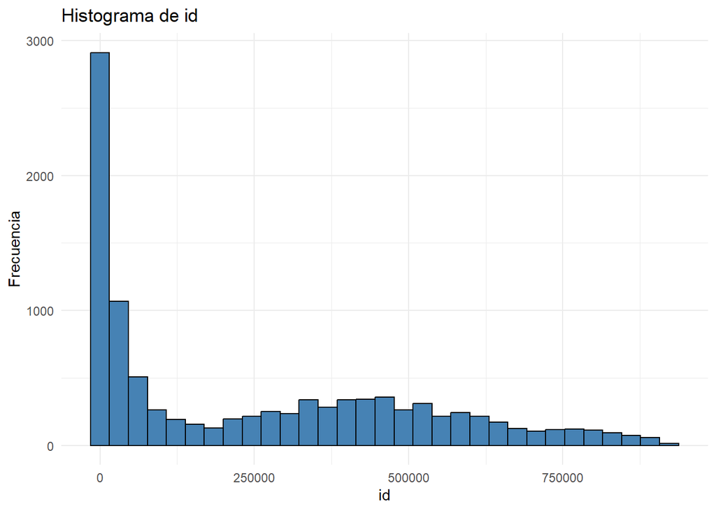

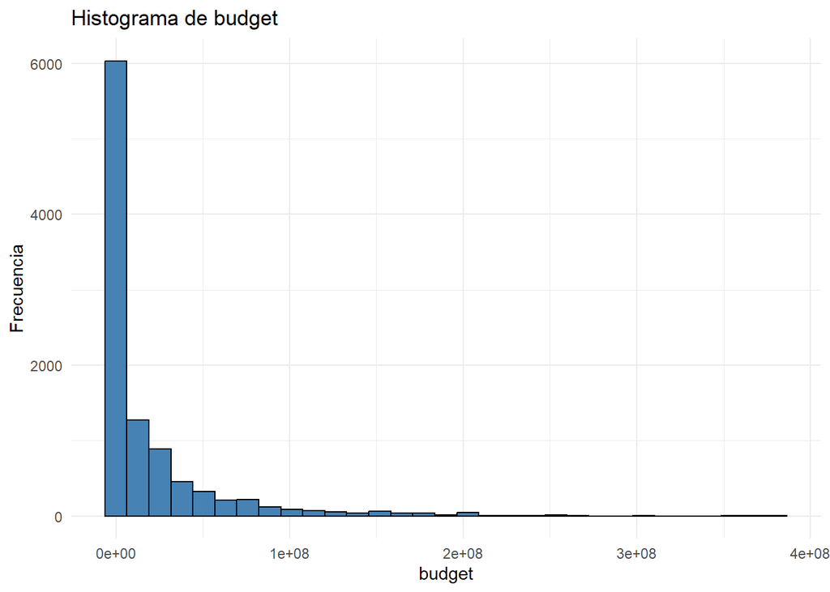

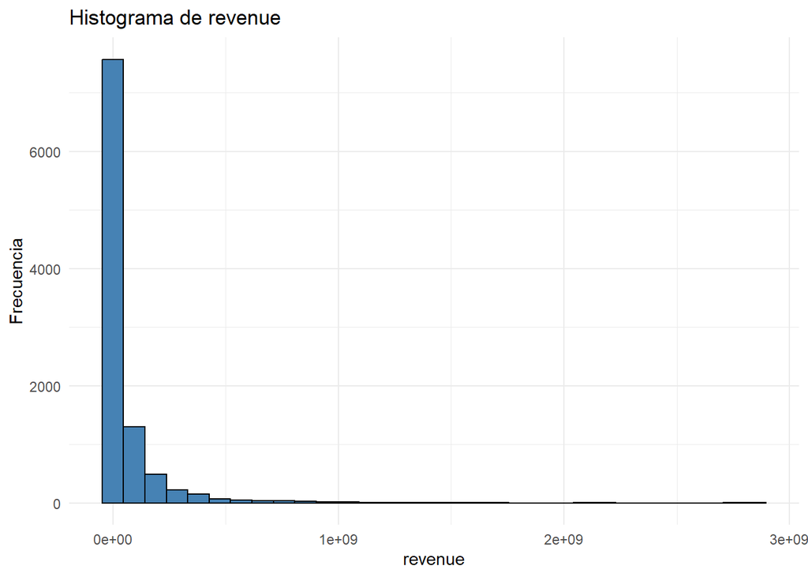

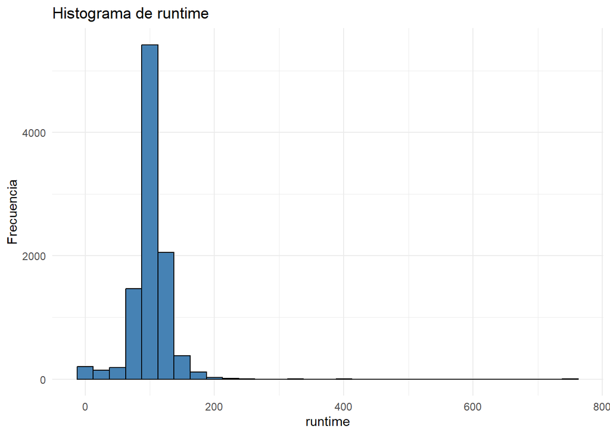

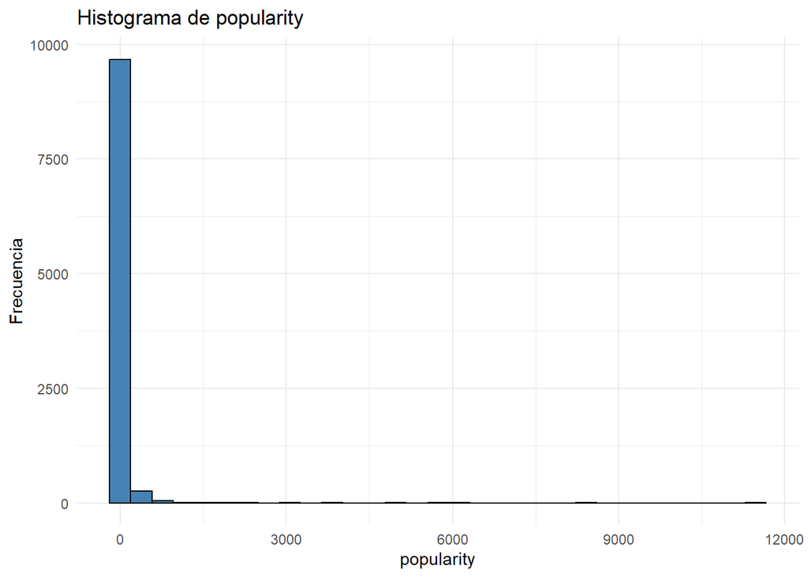

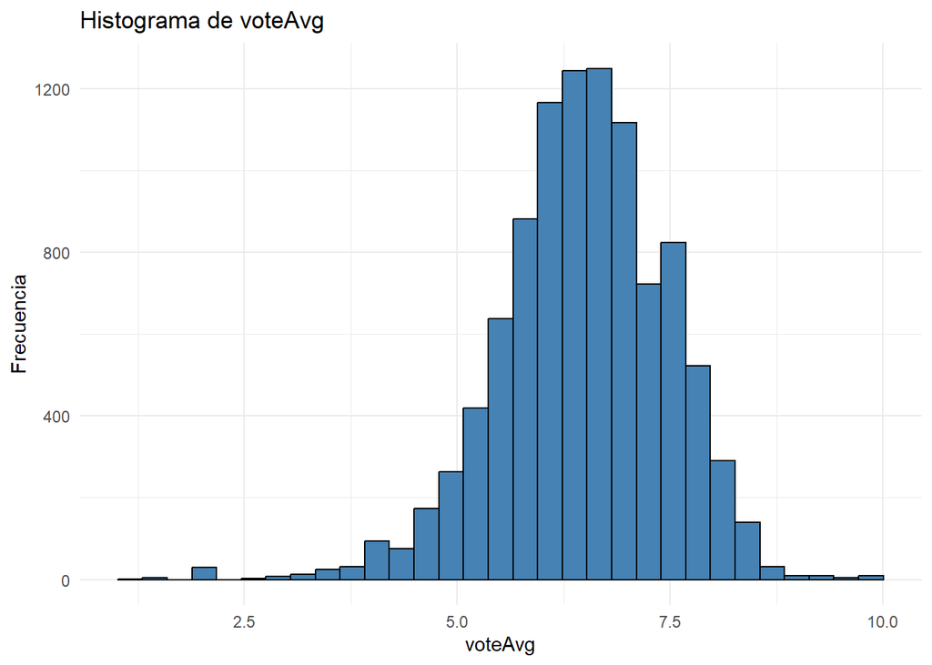

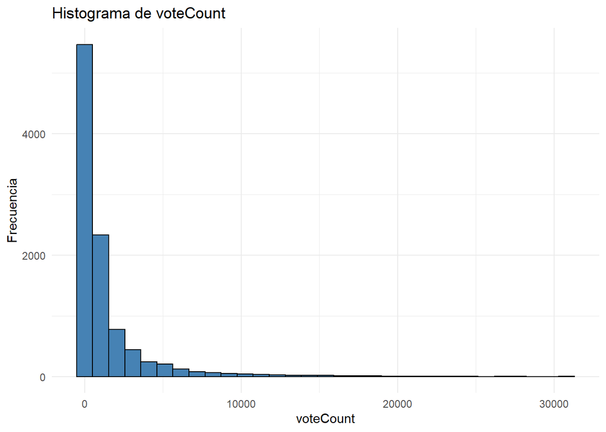

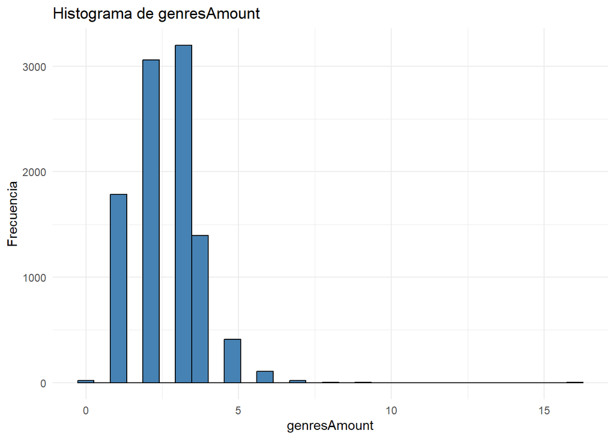

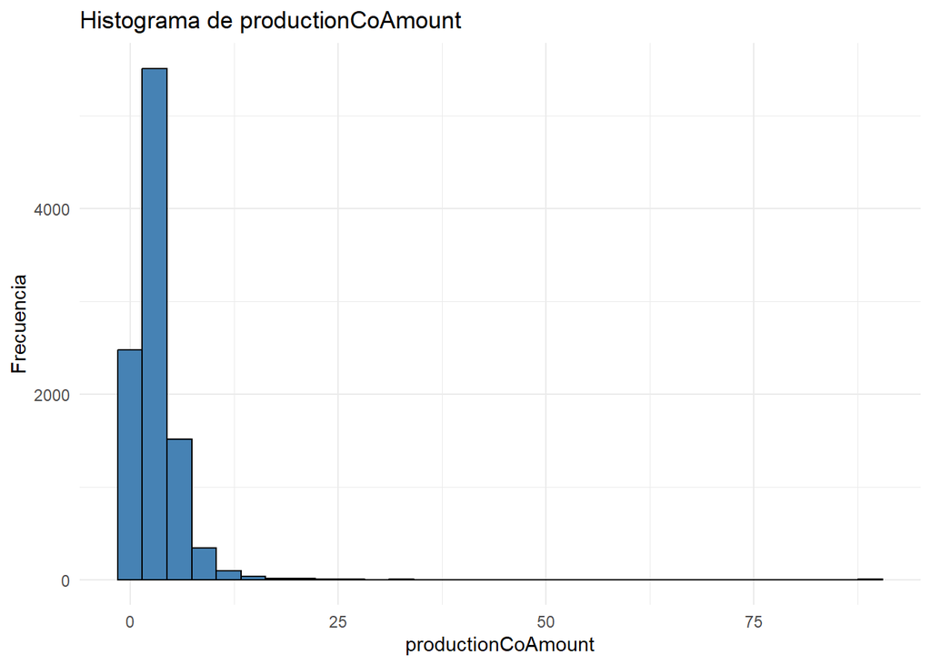

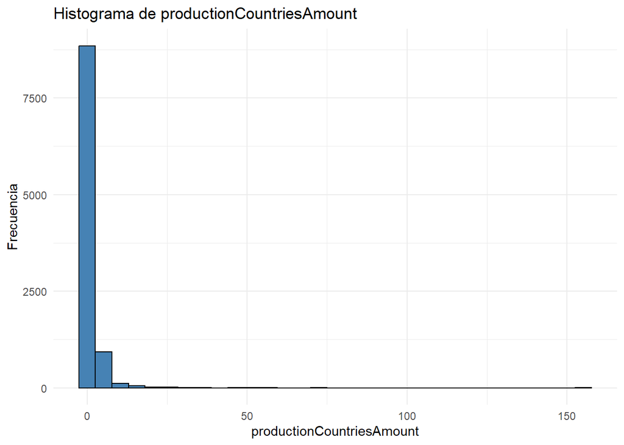

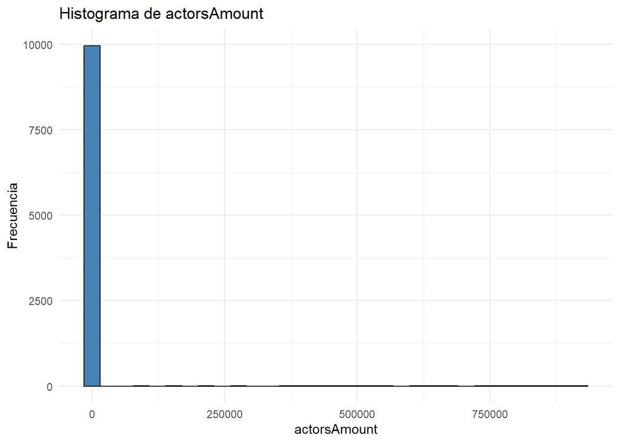

Como se puede observar de todas las variables numericas, realmente la unica variable que sigue una distribucion normal casi simetrica, es el promedio de nota de las peliculas. No es completamente simetrica ya que se observa un ligero sesgo negativo (sesgo a la izquierda). Luego de eso casi todos los histogramas tienen una distribucion con sesgo positivo (a la derecha).

Segun probamos algunas consultas simples, esto puede estar ocurriendo por vaalores atipicos extremos. Por ejemplo en la cantidad de actores “actorsAmount” hay peliculas donde hay miles. La pelicula con mas actores tuvo **919590** por ejemplo. Hay algunas columnas que tienen una gran cantidad de datos atipicos.

## Tipo de cada una de las variables.

table de Variables de CineAnalysis

| Variable | Description | Type |
| --- | --- | --- |
| Id | Id de la pelicula | Cualitativa nominal |
| popularity | Índice de popularidad de la pelicula calculado semanalmente | Cuantitativa continua |
| budget | El presupuesto para la pelicula. | Cuantitativa discreta |
| revenue | El ingreso de la pelicula | Cuantitativa discreta |
| original_title | El titulo original de la pelicula, en su idioma original. | Cualitativa nominal |
| originalLanguage | Idioma original en que se encuentra la pelicula | Cualitativa nominal |
| title | El titulo de la pelicula traducido al ingles | Cualitativa nominal |
| homePage | La página de inicio de la pelicula | Cualitativa nominal |
| video | Si tiene videos promocionales o no | Cualitativa nominal |
| director | Director de la pelicula | Cualitativa nominal |
| runtime | La duración de la pelicula | Cuantitativa continua |
| genres | El género de la pelicula | Cualitativa nominal |
| genresAmount | Cantidad de géneros que representan la pelicula | Cuantitativa discreta |
| productionCompany | Las companias productoras de la pelicula | Cualitativa nominal |
| productionCoAmount | Cantidad de companias productoras que participaron en la pelicula | Cuantitativa discreta |
| productionCompanyCountry | Países de las companias productoras de la pelicula | Cualitativa nominal |
| productionCountry | Países en los que se llevó a cabo la producción de la pelicula | Cualitativa nominal |
| productionCountriesAmount | Cantidad de países en los que se rodó la pelicula | Cuantitativa discreta |
| releaseDate | Fecha de lanzamiento de la pelicula | Cuantitativa discreta |
| voteCount | El número de votos en la plataforma para la pelicula. | Cuantitativa discreta |
| voteAvg | El promedio de los votos en la plataforma para la pelicula | Cuantitativa continua |
| actors | Actores que participan en la pelicula (Elenco) | Cualitativa nominal |
| actorsPopularity | Índice de popularidad del elenco de la pelicula. | Cuantitativa continua |
| actorsCharacter | Personaje que interpreta cada actor en la pelicula | Cualitativa nominal |
| actorsAmount | Cantidad de personas que actúan en la pelicula | Cuantitativa discreta |
| castWomenAmount | Cantidad de actrices en el elenco de la pelicula | Cuantitativa discreta |
| castMenAmount | Cantidad de actores en el elenco de la pelicula | Cuantitativa discreta |

## Tablas de frecuencia de Variables cualitativas

Los idiomas en los que más se producen peliculas son: inglés con un total de 7772, japonés con 644 y español en tercer lugar con 425.

| Idioma | Frecuencia |
| --- | --- |
| ar | 1 |
| bn | 1 |
| ca | 1 |
| cn | 80 |
| cs | 2 |
| da | 27 |
| de | 84 |
| el | 2 |
| en | 7772 |
| es | 425 |
| eu | 1 |
| fa | 3 |
| fi | 8 |
| fr | 271 |
| he | 1 |
| hi | 27 |
| id | 12 |
| is | 4 |
| it | 100 |
| ja | 644 |
| ko | 167 |
| la | 1 |
| ml | 1 |
| ms | 1 |
| nb | 1 |
| nl | 18 |
| no | 28 |
| pl | 15 |
| pt | 43 |
| ro | 2 |
| ru | 67 |
| sr | 4 |
| sv | 27 |
| ta | 1 |
| te | 5 |
| th | 17 |
| tl | 5 |
| tr | 10 |
| uk | 2 |
| zh | 119 |

Más del 90% de las peliculas no tienen un vídeo promocional, ya que apenas 84 peliculas sí cuentan con uno, mientras que 9430 no.

| Video | Frecuencia |
| --- | --- |
| FALSE | 9430 |
| TRUE | 84 |

Los directores más frecuente: Steven Spielberg con 30 , Clint con Eastwood 28 y Ridley Scott 23

Top 10 Directores por Frecuencia

| Director | Frecuencia |
| --- | --- |
| Steven Spielberg | 30 |
| Clint Eastwood | 28 |
| Ridley Scott | 23 |
| Sam Liu | 22 |
| Kunihiko Yuyama | 21 |
| Robert Rodriguez | 21 |
| Martin Scorsese | 19 |
| Steven Soderbergh | 19 |
| Joel Coen | 18 |
| Robert Zemeckis | 18 |

Top 10 compañías de Producción por Frecuencia

| ProductionCompany | Frecuencia |
| --- | --- |
| Warner Bros. Pictures | 480 |
| Universal Pictures | 466 |
| Columbia Pictures | 347 |
| Paramount | 320 |
| 20th Century Fox | 310 |
| Walt Disney Pictures | 221 |
| New Line Cinema | 176 |
| Lionsgate | 168 |
| Canal+ | 167 |
| Metro-Goldwyn-Mayer | 161 |

Top 10 Países de compañías de Producción por Frecuencia

| ProductionCompanyCountry | Frecuencia |
| --- | --- |
| US | 12675 |
| JP | 1604 |
| FR | 1478 |
| GB | 1413 |
| DE | 511 |
| CA | 507 |
| ES | 463 |
| KR | 395 |
| BE | 255 |
| IT | 246 |

Los países en los que más se llevan a cabo peliculas son Estados Unidos con un total de 6788, seeguido de Reino Unido con 1171 y Japón con 731.

Top 10 Países de Producción por Frecuencia

| ProductionCountry | Frecuencia |
| --- | --- |
| United States of America | 6788 |
| United Kingdom | 1171 |
| Japan | 731 |
| France | 668 |
| Canada | 634 |
| Germany | 507 |
| Spain | 282 |
| China | 231 |
| Italy | 210 |
| Australia | 188 |

Existe un total de 480 peliculas animadas que en las que no participa ningún actor per se. Frank Welker es el actor que en más peliculas ha aprecido con 143 incidencias, seguido de Grey DeLisle con 97 y por muy poco Jeff Bennett con 91.

Top 10 Actores por Frecuencia

| Actor | Frecuencia |
| --- | --- |
| FALSE | 480 |
| Frank Welker | 143 |
| Grey DeLisle | 97 |
| Jeff Bennett | 91 |
| Fred Tatasciore | 86 |
| Samuel L. Jackson | 85 |
| Dee Bradley Baker | 82 |
| Bruce Willis | 80 |
| Kevin Michael Richardson | 79 |
| Tara Strong | 79 |